# Outreachy_Olamide_Contribution_2023

## Analysis Of Moja Global Datasets To Evaluate The Congo Basin Forest Ecoregion

1. Introduction
2. Administrative Boundaries
3. Soil resources
4. Land Cover

**`Introduction:`**

The Congo Basin forest ecoregion (Olson and Dinerstein, 2002) is comprised of tropical forests in the Democratic Republic of Congo (DRC), Republic of Congo (ROC), Equatorial Guinea, Gabon, Cameroon, Central Africa Republic, and a small portion of Angola (Fig. 1). This represents the largest connected tract of forest in Africa, and the single largest peatland complex in the world, storing a significant amount of forest carbon [Dargie et al., 2017](https://www.sciencedirect.com/science/article/pii/S1470160X20312085#b0075)

The basin is highly biodiverse and is a focus of recent species discovery [Dargie et al., 2019](https://www.sciencedirect.com/science/article/pii/S1470160X20312085#b0065), [Hart et al., 2012](https://www.sciencedirect.com/science/article/pii/S1470160X20312085#b0135), while more than 30 million people inhabit the basin, including indigenous communities with a long and intricate relationship to natural ecosystems [Riddell, 2013](https://www.sciencedirect.com/science/article/pii/S1470160X20312085#b0300). Together these characteristics represent a unique ecological opportunity to mitigate climate, while supporting the livelihoods of the many communities who depend on essential natural resources.

The relative lack of current geo-spatial information on forests, and few validation information from the ground due to lack of access or security, political instability; or widely distributed studies on land-use related impacts on forests and associated species biodiversity, for example in compared to the Amazon basin or Asian forests currently hinders successful management and conservation efforts in the context of needed sustainable development [Malhi et al., 2013](https://www.sciencedirect.com/science/article/pii/S1470160X20312085#b0195).

The Congo Basin rainforest is the second-largest in the world, covering almost 200 million ha of humid tropical forest. It plays a crucial role in the global climate cycle and provides local livelihoods and resources for more than 100 million people across six countries: Cameroon, Central African Republic, the Democratic Republic of the Congo, Equatorial Guinea, Gabon and the Republic of the Congo (Somorin et al [2012](https://www.researchgate.net/?_tp=eyJjb250ZXh0Ijp7InBhZ2UiOiJwdWJsaWNhdGlvbiIsInByZXZpb3VzUGFnZSI6Il9kaXJlY3QifX0#)). Despite its importance, forest dynamics in the Congo Basin remain understudied compared to those in Amazon and Southeast Asian rainforests, and it is only recently that scientists have begun to systematically evaluate how and why Congo Basin forests are changing (Tyukavina et al [2018](https://www.researchgate.net/?_tp=eyJjb250ZXh0Ijp7InBhZ2UiOiJwdWJsaWNhdGlvbiIsInByZXZpb3VzUGFnZSI6Il9kaXJlY3QifX0#), Creese et al [2019](https://www.researchgate.net/?_tp=eyJjb250ZXh0Ijp7InBhZ2UiOiJwdWJsaWNhdGlvbiIsInByZXZpb3VzUGFnZSI6Il9kaXJlY3QifX0#), Kleinschroth et al [2019](https://www.researchgate.net/?_tp=eyJjb250ZXh0Ijp7InBhZ2UiOiJwdWJsaWNhdGlvbiIsInByZXZpb3VzUGFnZSI6Il9kaXJlY3QifX0#)).The rapidly growing population in the Congo Basin has led to an acceleration of forest disturb-ance rates over the past decades, with an estimated 16 million ha of forest cleared between 2000 and 2014 (Tyukavina et al [2018](https://www.researchgate.net/?_tp=eyJjb250ZXh0Ijp7InBhZ2UiOiJwdWJsaWNhdGlvbiIsInByZXZpb3VzUGFnZSI6Il9kaXJlY3QifX0#)). Smallholder agricul-ture causes the large majority of forest disturbances. Other major drivers include selective logging, mining, and road expansion (Potapov et al [2012](https://www.researchgate.net/?_tp=eyJjb250ZXh0Ijp7InBhZ2UiOiJwdWJsaWNhdGlvbiIsInByZXZpb3VzUGFnZSI6Il9kaXJlY3QifX0#), Tyukavina et al [2018](https://www.researchgate.net/?_tp=eyJjb250ZXh0Ijp7InBhZ2UiOiJwdWJsaWNhdGlvbiIsInByZXZpb3VzUGFnZSI6Il9kaXJlY3QifX0#), Umunay et al [2019](https://www.researchgate.net/?_tp=eyJjb250ZXh0Ijp7InBhZ2UiOiJwdWJsaWNhdGlvbiIsInByZXZpb3VzUGFnZSI6Il9kaXJlY3QifX0#)).

**`Landmass:`**

> The Congo Basin makes up one of the most important wilderness areas left on Earth. At 500 million acres, it is larger than the state of Alaska and stands as the world’s second-largest tropical forest. There are approximately 10, 000 species of tropical plants in the Congo Basin and 30 percent are unique to the region. Endangered wildlife, including forest elephants, chimpanzees, bonobos, and lowland and mountain gorillas inhabit the lush forests. 400 other species of mammals, 1,000 species of birds and 700 species of fish can also be found here. The Congo Basin has been inhabited by humans for more than 50,000 years and it provides food, fresh water and shelter to more than 75 million people. Nearly 150 distinct ethnic groups exist and the region’s Ba’Aka people are among the most well known representatives of an ancient hunter-gatherer lifestyle. Their lives and well-being are linked intimately with the forest.

**`Threats:`**

> A large and growing percentage of the Congo Basin is under concession to logging and mining companies. Such industries bring large groups of people to the forest and with that come their need for food, including bushmeat and fuelwood. Related infrastructure projects—such as roads and dams—have environmental impacts and increase access to remote forest areas for hunters. The leading cause of wildlife loss in the Congo Basin is the commercial bushmeat trade, driven by an ever increasing market. In the DRC alone, over a million tons of bushmeat are consumed each year. Alarmingly, this lucrative business is causing the forest to become empty of species. Animals like monkeys and antelope are common targets, although species such as gorillas and bonobos are also at risk.

**`Sources:`**

> 1. [Forest condition in the Congo Basin for the assessment of ecosystem conservation status](https://www.sciencedirect.com/science/article/pii/S1470160X20312085#b0425)
> 2. Forest disturbance alerts for the Congo Basin using Sentinel-1
> 3. [Moja Global Dataset](https://drive.google.com/drive/folders/1PZCVksHsuNyPzB9QTyraBSs1C7_c7W56?usp=drive_link)
> 4. [Image source for Fig 1](https://ars.els-cdn.com/content/image/1-s2.0-S1470160X20312085-gr1.jpg)
> 5. [World Wild Life](https://www.worldwildlife.org/places/congo-basin#:~:text=Adopt%20a%20Gorilla-,Facts,world's%20second%2Dlargest%20tropical%20forest.)

[figure not shown]

**`Fig 1`**

> *The regional study area encompasses 6 countries in the Congo Basin. A national scale assessment focuses on the Democratic Republic of Congo (DRC). Major biogeographic boundaries are defined by the Ubangi and Congo Rivers. Green shows the primary tropical forest cover for 2016.*

### Importing Libraries

```python
# install geopandas, this could take long
import geopandas as gpd

# for download and decompress the dataset
import os, zipfile, glob, io, requests

# for SIG and spatial info management
from shapely.geometry import Polygon, shape

# for SIG and spatial visualization
import folium
from folium import Choropleth
from folium.plugins import HeatMap

# for dataframes and numerical info management
import numpy as np
import pandas as pd

# for plot and graphs
import matplotlib.pyplot as plt
import seaborn as sns

# Ignore warning about missing/empty geometries
import warnings
warnings.filterwarnings('ignore', 'GeoSeries.notna', UserWarning)
plt.rcParams.update({'figure.max_open_warning': 0})
warnings.simplefilter("ignore", category=FutureWarning)

from matplotlib.patches import Patch  # Import the Patch class

import requests

# for dependencies
%matplotlib inline

!pip install gdown

!pip install contextily
```

#### Downloading World Data

```python
url = "https://www.naturalearthdata.com/http//www.naturalearthdata.com/download/110m/cultural/ne_110m_admin_0_countries.zip"
file_name = "ne_110m_admin_0_countries.zip"

headers = {
    'User-Agent': 'Your User-Agent String',
}

# Send an HTTP GET request with headers
response = requests.get(url, headers=headers)

if response.status_code == 200:
    with open(file_name, "wb") as file:
        file.write(response.content)
    print(f"File '{file_name}' downloaded successfully.")
else:
    print(f"Failed to download the file. Status code: {response.status_code}")
```

```
File 'ne_110m_admin_0_countries.zip' downloaded successfully.
```

```python
# importing the data
world_df = gpd.read_file("ne_110m_admin_0_countries.zip")
world_df.to_crs(epsg=4326, inplace=True)
```

```python
world_df.head(3)
```

|  | featurecla | scalerank | LABELRANK | SOVEREIGNT | SOV_A3 | ADM0_DIF | LEVEL | TYPE | TLC | ADMIN | ... | FCLASS_TR | FCLASS_ID | FCLASS_PL | FCLASS_GR | FCLASS_IT | FCLASS_NL | FCLASS_SE | FCLASS_BD | FCLASS_UA | geometry |
| --- | --- | --- | --- | --- | --- | --- | --- | --- | --- | --- | --- | --- | --- | --- | --- | --- | --- | --- | --- | --- | --- |
| 0 | Admin-0 country | 1 | 6 | Fiji | FJI | 0 | 2 | Sovereign country | 1 | Fiji | ... | None | None | None | None | None | None | None | None | None | MULTIPOLYGON (((180.00000 -16.06713, 180.00000... |
| 1 | Admin-0 country | 1 | 3 | United Republic of Tanzania | TZA | 0 | 2 | Sovereign country | 1 | United Republic of Tanzania | ... | None | None | None | None | None | None | None | None | None | POLYGON ((33.90371 -0.95000, 34.07262 -1.05982... |
| 2 | Admin-0 country | 1 | 7 | Western Sahara | SAH | 0 | 2 | Indeterminate | 1 | Western Sahara | ... | Unrecognized | Unrecognized | Unrecognized | None | None | Unrecognized | None | None | None | POLYGON ((-8.66559 27.65643, -8.66512 27.58948... |

3 rows × 169 columns

```python
# also the dataset is huge (162 features), so it need cleaning.
world_df = world_df[['CONTINENT','NAME_LONG', 'POP_EST', 'POP_YEAR', 'geometry']]
world_df.columns = world_df.columns.str.lower()
```

```python
world_df.head(1)
```

|  | continent | name_long | pop_est | pop_year | geometry |
| --- | --- | --- | --- | --- | --- |
| 0 | Oceania | Fiji | 889953.0 | 2019 | MULTIPOLYGON (((180.00000 -16.06713, 180.00000... |

```python
# Calculate centroids and store them in a 'centroid' column
world_df['centroid'] = world_df.geometry.centroid
```

```python
# Check the current CRS
print(world_df.crs)
world_df = world_df.to_crs(epsg=3857)

# Calculate centroids and store them in a 'centroid' column
world_df['centroid'] = world_df.geometry.centroid
```

```
EPSG:4326
```

```python
world_df.head(5)
```

|  | continent | name_long | pop_est | pop_year | geometry | centroid |
| --- | --- | --- | --- | --- | --- | --- |
| 0 | Oceania | Fiji | 889953.0 | 2019 | MULTIPOLYGON (((20037508.343 -1812498.413, 200... | POINT (18248781.791 -1958098.338) |
| 1 | Africa | Tanzania | 58005463.0 | 2019 | POLYGON ((3774143.866 -105758.362, 3792946.708... | POINT (3869295.824 -700307.061) |
| 2 | Africa | Western Sahara | 603253.0 | 2017 | POLYGON ((-964649.018 3205725.605, -964597.245... | POINT (-1348402.527 2794163.183) |
| 3 | North America | Canada | 37589262.0 | 2019 | MULTIPOLYGON (((-13674486.249 6274861.394, -13... | POINT (-10797792.505 10444215.145) |
| 4 | North America | United States | 328239523.0 | 2019 | MULTIPOLYGON (((-13674486.249 6274861.394, -13... | POINT (-13297133.706 6667415.522) |

```python
# for the purpose of use this boundaries as a clipper, the african countries
# (filtered on the CONTINENT feature) using pandas like dataframe management
africa_df = world_df.loc[world_df.continent == 'Africa',]

# fixing data
africa_df = africa_df.reset_index(drop=True)
# africa_df.lastcensus = africa_df.lastcensus.astype(str).replace({'-99':'1999'}).astype(int)

# features for plot
africa_df['popu'] = africa_df['pop_est'] / 1e6 # get the population in millions
```

```python
# we show what the africa data looks like
africa_df.head()
```

|  | continent | name_long | pop_est | pop_year | geometry | centroid | popu |
| --- | --- | --- | --- | --- | --- | --- | --- |
| 0 | Africa | Tanzania | 58005463.0 | 2019 | POLYGON ((3774143.866 -105758.362, 3792946.708... | POINT (3869295.824 -700307.061) | 58.005463 |
| 1 | Africa | Western Sahara | 603253.0 | 2017 | POLYGON ((-964649.018 3205725.605, -964597.245... | POINT (-1348402.527 2794163.183) | 0.603253 |
| 2 | Africa | Democratic Republic of the Congo | 86790567.0 | 2019 | POLYGON ((3266113.592 -501451.658, 3286149.877... | POINT (2625640.686 -320374.987) | 86.790567 |
| 3 | Africa | Somalia | 10192317.3 | 2019 | POLYGON ((4629235.496 -187405.493, 4563319.886... | POINT (5091788.043 532430.284) | 10.192317 |
| 4 | Africa | Kenya | 52573973.0 | 2019 | POLYGON ((4363971.168 -521194.733, 4204192.077... | POINT (4206916.801 66475.626) | 52.573973 |

## Congo Basin Forest

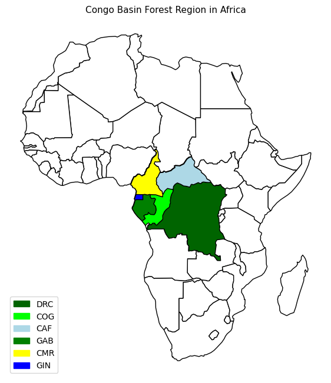

```python
# Define the countries and their corresponding colors
countries_and_colors = {
    "Democratic Republic of the Congo": ("DRC", "#006400"),
    "Republic of the Congo": ("COG", "#00FF00"),
    "Central African Republic": ("CAF", "#ADD8E6"),
    "Gabon": ("GAB", "#008000"),
    "Cameroon": ("CMR", "#FFFF00"),
    "Equatorial Guinea": ("GIN", "#0000FF")
}

# Create a Matplotlib figure and axis
fig, ax = plt.subplots(figsize=(7, 10))

# Plot the map of Africa with the specified countries and their colors
africa_df.plot(ax=ax, color='white', edgecolor='black')

legend_patches = []  # List to store legend patches and labels

for country, (abbreviation, color) in countries_and_colors.items():
    if country in africa_df['name_long'].values:
        selected_country = africa_df[africa_df['name_long'] == country]
        selected_country.plot(ax=ax, color=color, edgecolor='black')
        legend_patches.append(Patch(color=color, label=abbreviation))

# Set the title using Matplotlib
ax.set_title('Congo Basin Forest Region in Africa', fontsize=11)

# Create a legend using the custom legend_patches
ax.legend(handles=legend_patches, loc='lower left')

# Remove axis
ax.axis('off')

# Show the plot
plt.show()
```

## `Administrative Boundaries`

#### Administrative boundaries Democratic Republic of Congo (DRC)

```python
# Specify the path to your local GeoJSON file
DRC_file = r'Dataset\Administrative_Boundaries\COD_AL2_DemocraticRepublicoftheCongo.json'

# Load the GeoJSON file using GeoPandas
DRC_boundary_df = gpd.read_file(DRC_file)

# Select the desired columns
DRC_boundary_df = DRC_boundary_df[['name', 'geometry']]

# Set the CRS if needed
DRC_boundary_df.crs = "EPSG:4326"  # Assuming the data is in WGS84
```

#### Administrative boundaries Republic of Congo (Congo-Brazzaville) (COG)

```python
# Specify the path to your local GeoJSON file
Congo_Brazzaville_file = r'Dataset\Administrative_Boundaries\COG_AL2_Congo-Brazzaville.json'

# Load the GeoJSON file using GeoPandas
Congo_Brazzaville_boundary_df = gpd.read_file(Congo_Brazzaville_file)

# Select the desired columns
Congo_Brazzaville_boundary_df = Congo_Brazzaville_boundary_df[['name', 'geometry']]

# Set the CRS if needed
Congo_Brazzaville_boundary_df.crs = "EPSG:4326"  # Assuming the data is in WGS84
```

#### Administrative boundaries In Central African Republic (CAF)

```python
# Specify the path to your local GeoJSON file
Central_African_Republic_file = r'Dataset\Administrative_Boundaries\CAF_AL2_Central African Republic.json'

# Load the GeoJSON file using GeoPandas
Central_African_Republic_boundary_df = gpd.read_file(Central_African_Republic_file)

# Select the desired columns
Central_African_Republic_boundary_df = Central_African_Republic_boundary_df[['name', 'geometry']]

# Set the CRS if needed
Central_African_Republic_boundary_df.crs = "EPSG:4326"  # Assuming the data is in WGS84
```

#### Administrative boundaries Gabon (GAB)

```python
# Specify the path to your local GeoJSON file
Gabon_file = r'Dataset\Administrative_Boundaries\GAB_AL2_Gabon.json'

# Load the GeoJSON file using GeoPandas
Gabon_boundary_df = gpd.read_file(Gabon_file)

# Select the desired columns
Gabon_boundary_df = Gabon_boundary_df[['name', 'geometry']]

# Set the CRS if needed
Gabon_boundary_df.crs = "EPSG:4326"  # Assuming the data is in WGS84
```

#### Administrative boundaries Cameroon (CMR)

```python
# Specify the path to your local GeoJSON file
Cameroon_file = r'Dataset\Administrative_Boundaries\CMR_AL2_Cameroon.json'

# Load the GeoJSON file using GeoPandas
Cameroon_boundary_df = gpd.read_file(Cameroon_file)

# Select the desired columns
Cameroon_boundary_df = Cameroon_boundary_df[['name', 'geometry']]

# Set the CRS if needed
Cameroon_boundary_df.crs = "EPSG:4326"  # Assuming the data is in WGS84
```

```python
# Specify the path to your local GeoJSON file
Equatorial_Guinea_file = r'Dataset\Administrative_Boundaries\GIN_AL2_Guinea.json'

# Load the GeoJSON file using GeoPandas
Equatorial_Guinea_boundary_df = gpd.read_file(Equatorial_Guinea_file)

# Select the desired columns
Equatorial_Guinea_boundary_df = Equatorial_Guinea_boundary_df[['name', 'geometry']]

# Set the CRS if needed
Equatorial_Guinea_boundary_df.crs = "EPSG:4326"  # Assuming the data is in WGS84
```

#### Plot each country's boundary separately

[figure not shown]

```python
# Create a list of countries and their respective colors
countries = [
    ('Democratic Republic of the Congo', 'Dataset\Administrative_Boundaries\COD_AL2_DemocraticRepublicoftheCongo.json', '#006400'),
    ('Republic of Congo', 'Dataset\Administrative_Boundaries\COG_AL2_Congo-Brazzaville.json', '#00FF00'),
    ('Central African Republic', 'Dataset\Administrative_Boundaries\CAF_AL2_Central African Republic.json', '#ADD8E6'),
    ('Gabon', 'Dataset\Administrative_Boundaries\GAB_AL2_Gabon.json', '#008000'),
    ('Cameroon', 'Dataset\Administrative_Boundaries\CMR_AL2_Cameroon.json', '#FFFF00'),
    ('Equatorial Guinea', 'Dataset\Administrative_Boundaries\GIN_AL2_Guinea.json', '#0000FF')
]

# Create subplots with the same number of rows and columns
num_rows = 2
num_cols = 3

fig, axs = plt.subplots(num_rows, num_cols, figsize=(15, 10))

# Plot each country's boundary separately in its own subplot
for i, (country_name, file_path, color) in enumerate(countries):
    country_df = gpd.read_file(file_path)
    country_df = country_df[['name', 'geometry']]
    country_df.crs = "EPSG:4326"

    row = i // num_cols
    col = i % num_cols
    ax = axs[row, col]
    country_df.plot(ax=ax, color=color, edgecolor='Black')
    ax.set_title(f'Administrative boundaries {country_name}\n', fontsize=10)
    ax.axis('off')

plt.tight_layout()
plt.show()
```

## `Soil Resources`

```python
# File paths for Gabon, Cameroon, Democratic Republic of Congo, Central African Republic, Equatorial Guinea, and Congo-Brazzaville
gabon_soilresource = 'Dataset\Soil_Resources\GAB_AL2_Gabon_WSR.json'
cameroon_soilresource = 'Dataset\Soil_Resources\CMR_AL2_Cameroon_WSR.json'
drc_soilresource = 'Dataset\Soil_Resources\COD_AL2_Democratic Republic of the Congo_WSR.json'
caf_soilresource = 'Dataset\Soil_Resources\CAF_AL2_Central African Republic_WSR.json'
guinea_soilresource = 'Dataset\Soil_Resources\GNQ_AL2_Equatorial Guinea_WSR.json'
congobrazaville_soilresource = 'Dataset\Soil_Resources\COG_AL2_Congo-Brazzaville_WSR.json'

# Load the local data with geopandas
gabonSR_df = gpd.read_file(gabon_soilresource)
cameroonSR_df = gpd.read_file(cameroon_soilresource)
drcSR_df = gpd.read_file(drc_soilresource)
cafSR_df = gpd.read_file(caf_soilresource)
guineaSR_df = gpd.read_file(guinea_soilresource)
congobrazavilleSR_df = gpd.read_file(congobrazaville_soilresource)

# Standardize column names to lowercase
gabonSR_df.columns = gabonSR_df.columns.str.lower()
cameroonSR_df.columns = cameroonSR_df.columns.str.lower()
drcSR_df.columns = drcSR_df.columns.str.lower()
cafSR_df.columns = cafSR_df.columns.str.lower()
guineaSR_df.columns = guineaSR_df.columns.str.lower()
congobrazavilleSR_df.columns = congobrazavilleSR_df.columns.str.lower()

# Print dataset information
print('Gabon Soil dataset has %2d rows and %2d columns' %(gabonSR_df.shape[0], gabonSR_df.shape[1]))
print('Cameroon Soil dataset has %2d rows and %2d columns' %(cameroonSR_df.shape[0], cameroonSR_df.shape[1]))
print('DRC Soil dataset has %2d rows and %2d columns' %(drcSR_df.shape[0], drcSR_df.shape[1]))
print('Central African Republic Soil dataset has %2d rows and %2d columns' %(cafSR_df.shape[0], cafSR_df.shape[1]))
print('Equatorial Guinea Soil dataset has %2d rows and %2d columns' %(guineaSR_df.shape[0], guineaSR_df.shape[1]))
print('Congo-Brazzaville Soil dataset has %2d rows and %2d columns' %(congobrazavilleSR_df.shape[0], congobrazavilleSR_df.shape[1]))
```

```
Gabon Soil dataset has  2 rows and  8 columns
Cameroon Soil dataset has  9 rows and  8 columns
DRC Soil dataset has  6 rows and  8 columns
Central African Republic Soil dataset has  5 rows and  8 columns
Equatorial Guinea Soil dataset has  2 rows and  8 columns
Congo-Brazzaville Soil dataset has  3 rows and  8 columns
```

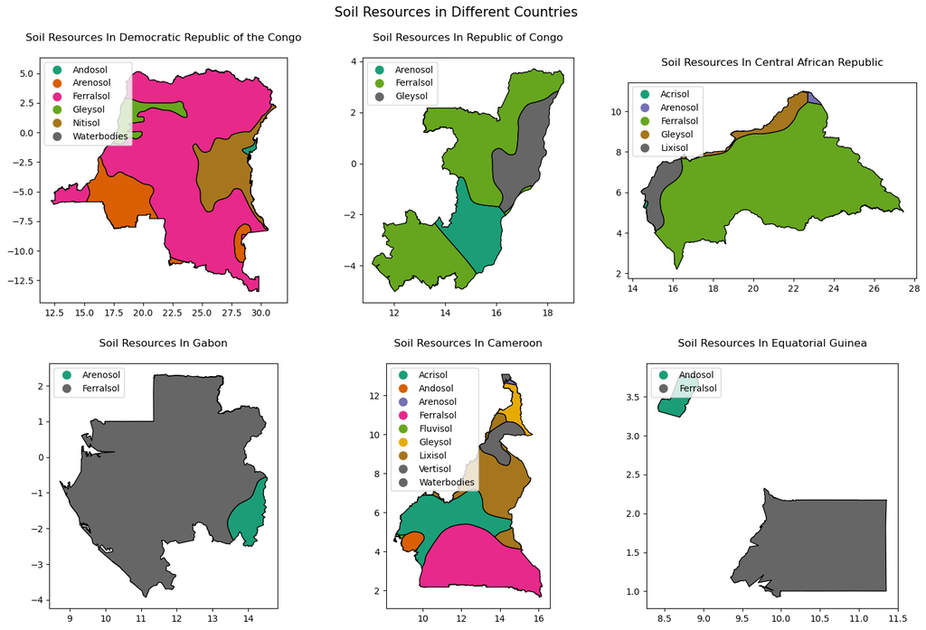

```python
def plot_soil_resources(dataframe, title, ax):
    # Set the title
    ax.set_title(f'\nSoil Resources In {title}\n', fontsize=12)

    # Plot the data
    dataframe.plot(ax=ax, column='ipcc', cmap='Dark2', edgecolor='black',
                  legend=True, legend_kwds={'loc': 'upper left'})

# Create a single map for all subplots
fig, axes = plt.subplots(2, 3, figsize=(15, 10))
fig.suptitle('Soil Resources in Different Countries', fontsize=15)

# Replace 'gabonSR_df' with each of the dataframes and appropriate titles
plot_soil_resources(drcSR_df, 'Democratic Republic of the Congo', axes[0, 0])
plot_soil_resources(congobrazavilleSR_df, 'Republic of Congo', axes[0, 1])
plot_soil_resources(cafSR_df, 'Central African Republic', axes[0, 2])
plot_soil_resources(gabonSR_df, 'Gabon', axes[1, 0])
plot_soil_resources(cameroonSR_df, 'Cameroon', axes[1, 1])
plot_soil_resources(guineaSR_df, 'Equatorial Guinea', axes[1, 2])

# Adjust the layout
plt.tight_layout()
plt.subplots_adjust(top=0.9)

# Show the plot
plt.show()
```

`Observations`

> - Huge dominance of Ferralsol in Gabon, Central African Republic, Congo, DRC and Guinea
> - Cameroon: evenly rich in various soil resources

## `Land Cover`

`Examining Just three Countries according to the available datasets on moja global for planted forests SDPT`

- Democratic Republic of Congo (DRC)
- Cameroon
- Gabon

```python
# File paths for Gabon, Cameroon, and Democratic Republic of Congo
gabon_path = 'Dataset\Land_Cover\GAB_Gabon_SDPT.json'
cameroon_path = 'Dataset\Land_Cover\CMR_Cameroon_SDPT.json'
drc_path = 'Dataset\Land_Cover\COD_Democratic Republic of Congo_SDPT.json'

# Load the local data with geopandas
gabon_df = gpd.read_file(gabon_path)
cameroon_df = gpd.read_file(cameroon_path)
drc_df = gpd.read_file(drc_path)

# Set the CRS to EPSG:4326 for all three dataframes
gabon_df = gabon_df.to_crs(epsg=4326)
cameroon_df = cameroon_df.to_crs(epsg=4326)
drc_df = drc_df.to_crs(epsg=4326)

# Fix the data by removing 'Unknown' and 'n/a' values
gabon_df = gabon_df.replace('Unknown', np.nan)
gabon_df = gabon_df.replace('n/a', np.nan)

cameroon_df = cameroon_df.replace('Unknown', np.nan)
cameroon_df = cameroon_df.replace('n/a', np.nan)

drc_df = drc_df.replace('Unknown', np.nan)
drc_df = drc_df.replace('n/a', np.nan)

# Subset important variables
gabon_df = gabon_df.rename(columns={'size': 'size_tree'})
gabon_df = gabon_df[['species', 'species_simp', 'common_name', 'plant_ag',
                     'timber_ag', 'ever_dec', 'conifer_broad', 'hard_soft',
                     'size_tree', 'year', 'org_name', 'geometry']]

cameroon_df = cameroon_df.rename(columns={'size': 'size_tree'})
cameroon_df = cameroon_df[['species', 'species_simp', 'common_name', 'plant_ag',
                           'timber_ag', 'ever_dec', 'conifer_broad', 'hard_soft',
                           'size_tree', 'year', 'org_name', 'geometry']]

drc_df = drc_df.rename(columns={'size': 'size_tree'})
drc_df = drc_df[['species', 'species_simp', 'common_name', 'plant_ag',
                 'timber_ag', 'ever_dec', 'conifer_broad', 'hard_soft',
                 'size_tree', 'year', 'org_name', 'geometry']]

print('Gabon dataset has %2d rows and %2d columns' % (gabon_df.shape[0], gabon_df.shape[1]))
print('Cameroon dataset has %2d rows and %2d columns' % (cameroon_df.shape[0], cameroon_df.shape[1]))
print('Democratic Republic of Congo (DRC) dataset has %2d rows and %2d columns' % (drc_df.shape[0], drc_df.shape[1]))
```

```
Gabon dataset has  1 rows and 12 columns
Cameroon dataset has 697 rows and 12 columns
Democratic Republic of Congo (DRC) dataset has 402 rows and 12 columns
```

#### `Cameroon Species Distribution Map, Species Count, Plant Agriculture Distribution, Timber Agriculture Distribution`

```python
cameroon_df.head(2)
```

|  | species | species_simp | common_name | plant_ag | timber_ag | ever_dec | conifer_broad | hard_soft | size_tree | year | org_name | geometry |
| --- | --- | --- | --- | --- | --- | --- | --- | --- | --- | --- | --- | --- |
| 0 | Musa sp. | Fruit | Banana | Tree crops | Tree crops | NaN | NaN | NaN | NaN | NaN | banana | POLYGON ((9.42913 4.16767, 9.42261 4.17375, 9.... |
| 1 | Musa sp. | Fruit | Banana | Tree crops | Tree crops | NaN | NaN | NaN | NaN | NaN | banana | POLYGON ((9.46926 4.16366, 9.46762 4.17146, 9.... |

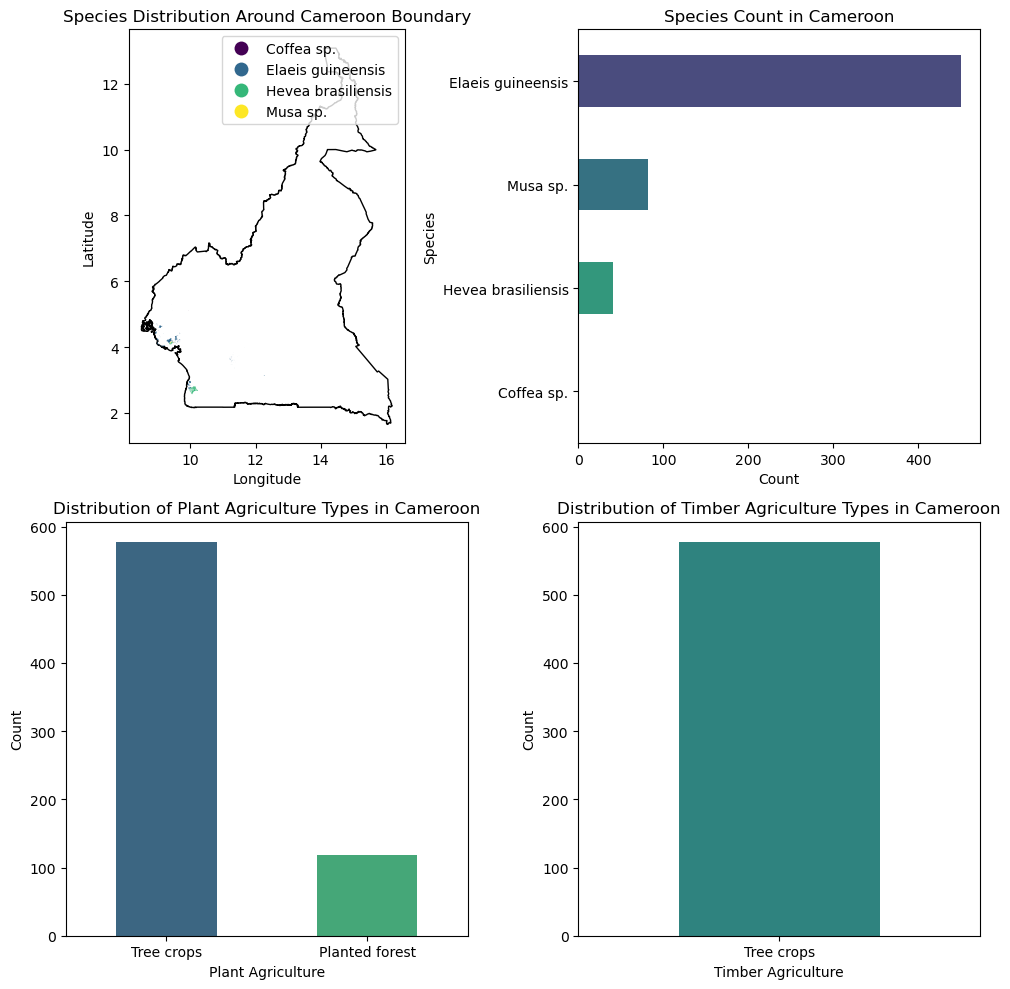

```python
# Create subplots
fig, axes = plt.subplots(2, 2, figsize=(10, 10))

# Species Distribution Map
Cameroon_boundary_df.plot(ax=axes[0, 0], edgecolor='black', color='none', linewidth=1)
cameroon_df.plot(ax=axes[0, 0], column='species', cmap='viridis', legend=True, legend_kwds={'bbox_to_anchor': (1, 1)}, markersize=20)
axes[0, 0].set_xlabel('Longitude')
axes[0, 0].set_ylabel('Latitude')
axes[0, 0].set_title('Species Distribution Around Cameroon Boundary')

# Species Count
species_count = cameroon_df['species'].value_counts()
sns.barplot(x=species_count.values, y=species_count.index, palette='viridis', ax=axes[0, 1], width=0.5)
axes[0, 1].set_xlabel('Count')
axes[0, 1].set_ylabel('Species')
axes[0, 1].set_title('Species Count in Cameroon')

# Plant Agriculture Distribution
sns.countplot(data=cameroon_df, x='plant_ag', palette='viridis', ax=axes[1, 0], width=0.5)
axes[1, 0].set_xlabel('Plant Agriculture')
axes[1, 0].set_ylabel('Count')
axes[1, 0].set_title('Distribution of Plant Agriculture Types in Cameroon')

# Timber Agriculture Distribution
sns.countplot(data=cameroon_df, x='timber_ag', palette='viridis', ax=axes[1, 1], width=0.5)
axes[1, 1].set_xlabel('Timber Agriculture')
axes[1, 1].set_ylabel('Count')
axes[1, 1].set_title('Distribution of Timber Agriculture Types in Cameroon')

# Adjust layout
plt.tight_layout()

# Show the subplots
plt.show()
```

#### `DRC Species Distribution Map, Species Count, Plant Agriculture Distribution, Timber Agriculture Distribution`

```python
drc_df.head(1)
```

|  | species | species_simp | common_name | plant_ag | timber_ag | ever_dec | conifer_broad | hard_soft | size_tree | year | org_name | geometry |
| --- | --- | --- | --- | --- | --- | --- | --- | --- | --- | --- | --- | --- |
| 0 | Dacryodes edulis | Fruit | African Pear | Tree crops | Tree crops | NaN | NaN | NaN | NaN | 2013 | African pear | POLYGON ((15.09726 -4.56273, 15.09707 -4.56255... |

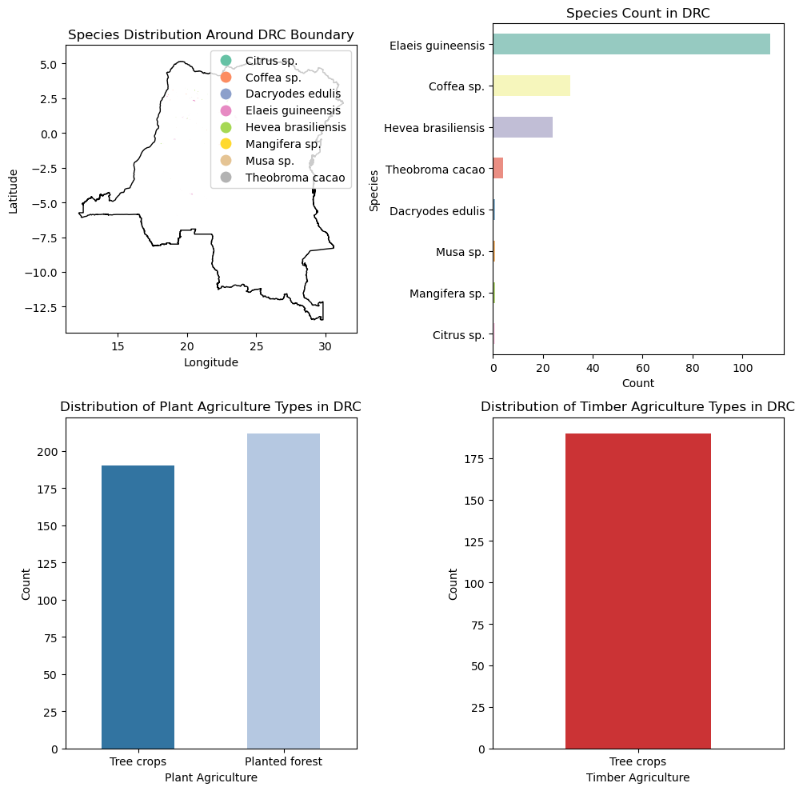

```python
# Create subplots
fig, axes = plt.subplots(2, 2, figsize=(10, 10))

# Species Distribution Map
DRC_boundary_df.plot(ax=axes[0, 0], edgecolor='black', color='none', linewidth=1)
drc_df.plot(ax=axes[0, 0], column='species', cmap='Set2', legend=True, legend_kwds={'bbox_to_anchor': (1, 1)}, markersize=10)  # Change palette to 'Set2'
axes[0, 0].set_xlabel('Longitude')
axes[0, 0].set_ylabel('Latitude')
axes[0, 0].set_title('Species Distribution Around DRC Boundary')

# Species Count
species_count = drc_df['species'].value_counts()
sns.barplot(x=species_count.values, y=species_count.index, palette='Set3', ax=axes[0, 1], width=0.5)  # Change palette to 'Set3'
axes[0, 1].set_xlabel('Count')
axes[0, 1].set_ylabel('Species')
axes[0, 1].set_title('Species Count in DRC')

# Plant Agriculture Distribution
sns.countplot(data=drc_df, x='plant_ag', palette='tab20', ax=axes[1, 0], width=0.5)  # Change palette to 'tab20'
axes[1, 0].set_xlabel('Plant Agriculture')
axes[1, 0].set_ylabel('Count')
axes[1, 0].set_title('Distribution of Plant Agriculture Types in DRC')

# Timber Agriculture Distribution
sns.countplot(data=drc_df, x='timber_ag', palette='Set1', ax=axes[1, 1], width=0.5)  # Change palette to 'Set1'
axes[1, 1].set_xlabel('Timber Agriculture')
axes[1, 1].set_ylabel('Count')
axes[1, 1].set_title('Distribution of Timber Agriculture Types in DRC')

# Adjust layout
plt.tight_layout()

# Show the subplots
plt.show()
```

### Gabon Species Distribution Map, Species Count, Plant Agriculture Distribution, Timber Agriculture Distribution

```python
gabon_df.head(3)
```

|  | species | species_simp | common_name | plant_ag | timber_ag | ever_dec | conifer_broad | hard_soft | size_tree | year | org_name | geometry |
| --- | --- | --- | --- | --- | --- | --- | --- | --- | --- | --- | --- | --- |
| 0 | Elaeis guineensis | Oil Palm | Oil Palm | Tree crops | Tree crops | NaN | NaN | NaN | NaN | 2013-2015 | oil palm | POLYGON ((10.18658 0.02564, 10.18734 0.02907, ... |

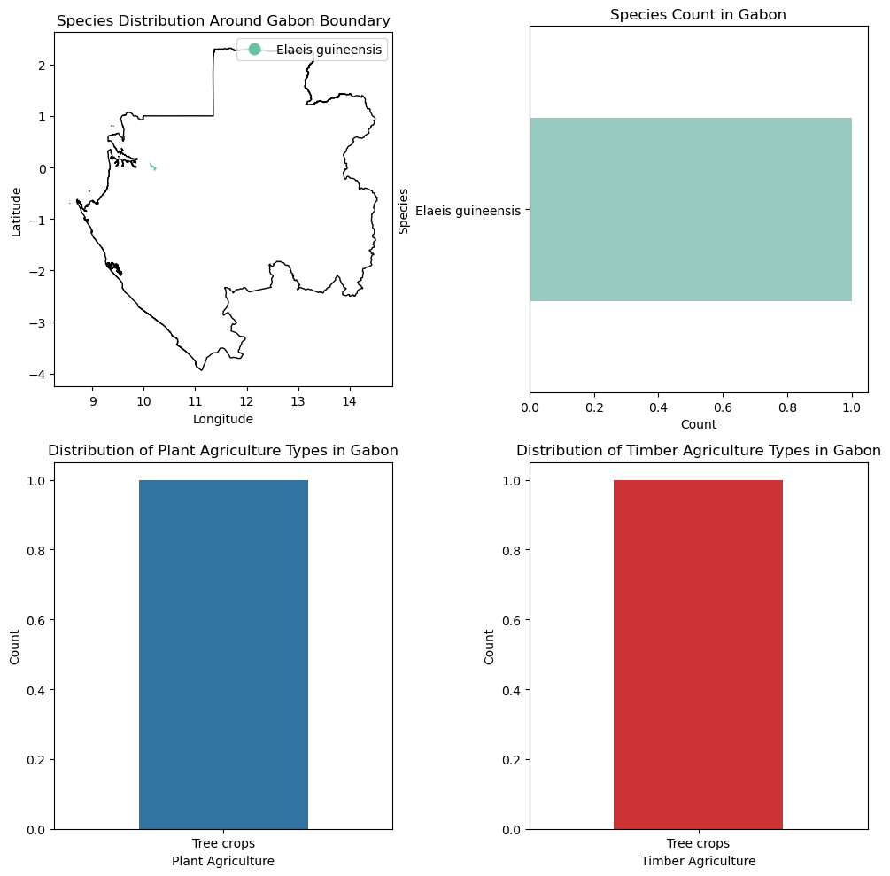

```python
# Create subplots
fig, axes = plt.subplots(2, 2, figsize=(10, 10))

# Species Distribution Map
Gabon_boundary_df.plot(ax=axes[0, 0], edgecolor='black', color='none', linewidth=1)
gabon_df.plot(ax=axes[0, 0], column='species', cmap='Set2', legend=True, legend_kwds={'bbox_to_anchor': (1, 1)}, markersize=10)
axes[0, 0].set_xlabel('Longitude')
axes[0, 0].set_ylabel('Latitude')
axes[0, 0].set_title('Species Distribution Around Gabon Boundary')

# Species Count
species_count = gabon_df['species'].value_counts()
sns.barplot(x=species_count.values, y=species_count.index, palette='Set3', ax=axes[0, 1], width=0.5)  # Change palette to 'Set3'
axes[0, 1].set_xlabel('Count')
axes[0, 1].set_ylabel('Species')
axes[0, 1].set_title('Species Count in Gabon')

# Plant Agriculture Distribution
sns.countplot(data=gabon_df, x='plant_ag', palette='tab20', ax=axes[1, 0], width=0.5)  # Change palette to 'tab20'
axes[1, 0].set_xlabel('Plant Agriculture')
axes[1, 0].set_ylabel('Count')
axes[1, 0].set_title('Distribution of Plant Agriculture Types in Gabon')

# Timber Agriculture Distribution
sns.countplot(data=gabon_df, x='timber_ag', palette='Set1', ax=axes[1, 1], width=0.5)  # Change palette to 'Set1'
axes[1, 1].set_xlabel('Timber Agriculture')
axes[1, 1].set_ylabel('Count')
axes[1, 1].set_title('Distribution of Timber Agriculture Types in Gabon')

# Adjust layout
plt.tight_layout()

# Show the subplots
plt.show()
```